# Seasonal and Harmonic Trend Modeling in Time Series

```r
library(tseries)
sign_resid <- ifelse(std_resid_quad > 0, 1, -1)

runs.test(factor(sign_resid))
```

```
##
##  Runs Test
##
## data:  factor(sign_resid)
## Standard Normal = -2.5607, p-value = 0.01045
## alternative hypothesis: two.sided
```

Since the p-value < 0.05, we reject the null hypothesis that the residuals are randomly distributed. This suggests that there is some non-random pattern in the residuals.

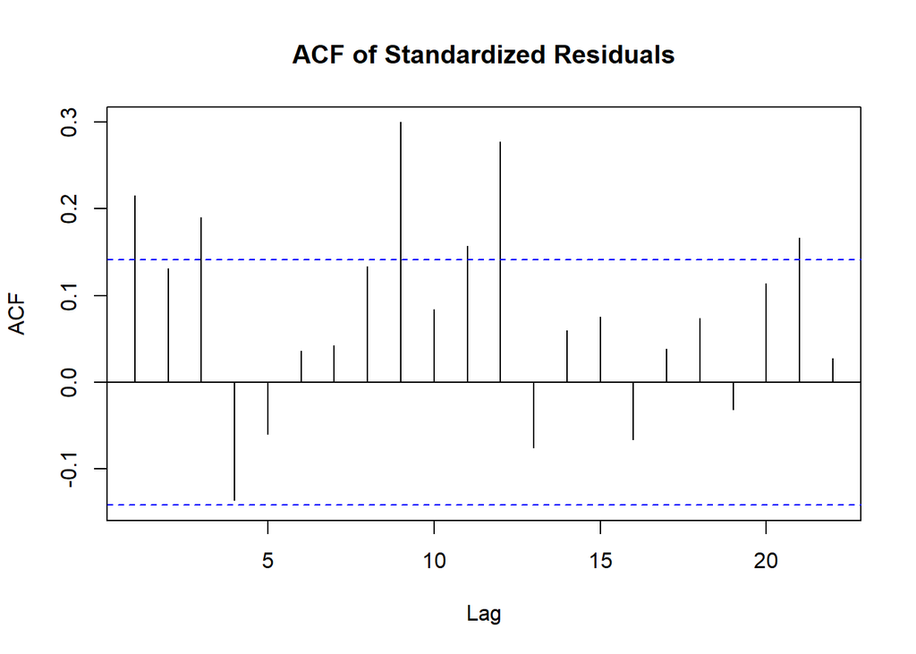

```r
acf(std_resid_quad, main="ACF of Standardized Residuals")
```

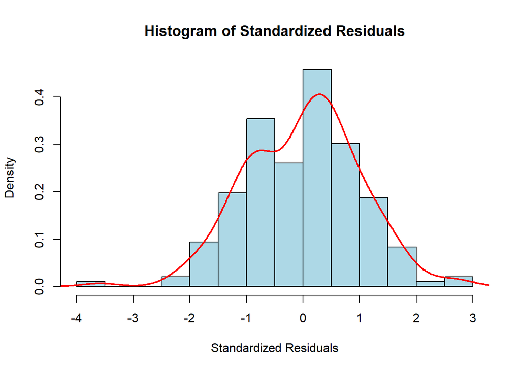

```r
hist(std_resid_quad, breaks=15, probability=TRUE, col="lightblue",
     main="Histogram of Standardized Residuals", xlab="Standardized Residuals")
lines(density(std_resid_quad), col="red", lwd=2)
```

The histogram of standardized residuals appears approximately symmetric and bell-shaped, closely resembling a normal distribution. The overlaid density curve (in red) follows the histogram reasonably well, though there may be slight deviations in the tails. There is no significant skewness, and extreme values seem minimal, suggesting that the residuals are roughly normally distributed.

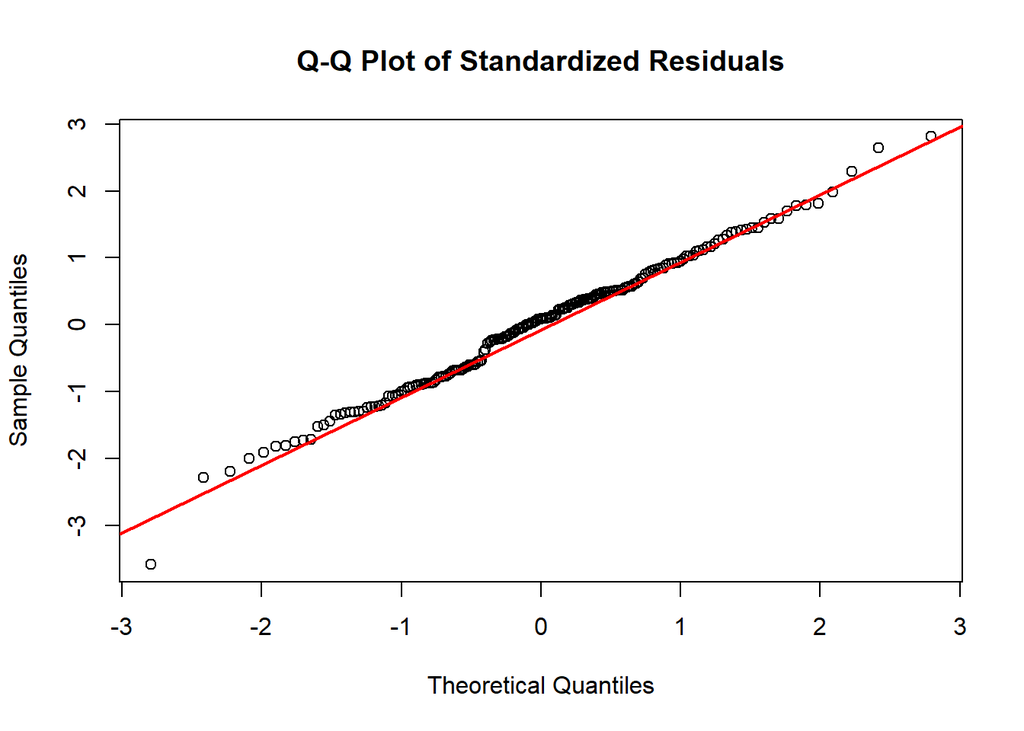

```r
qqnorm(std_resid_quad, main="Q-Q Plot of Standardized Residuals")
qqline(std_resid_quad, col="red", lwd=2)
```

$$Y_t = 5e_t + \frac{1}{2} e_{t-1} + \frac{1}{4} e_{t-2}$$

## **Autocorrelation Function Derivation**

We consider the **stationary process**:

$$Y_t = 5e_t + \frac{1}{2} e_{t-1} + \frac{1}{4} e_{t-2}$$

where $e_t$ is **white noise** with:

$$E[e_t] = 0, \quad \text{Var}(e_t) = \sigma^2.$$

### **Step 1: Compute the Mean of $Y_t$**

$$E[Y_t] = E\left[5e_t + \frac{1}{2} e_{t-1} + \frac{1}{4} e_{t-2} \right]
= 0.$$

Thus, $Y_t$ has **zero mean**.

### **Step 2: Compute the Variance of $Y_t$**

$$\text{Var}(Y_t) = E[Y_t^2] = 25\sigma^2 + \frac{1}{4} \sigma^2 +
\frac{1}{16} \sigma^2.$$

$$\text{Var}(Y_t) = 25.3125 \sigma^2.$$

### **Step 3: Compute the Autocovariance Function $\gamma_k$**

For $k = 0$:

$$\gamma_0 = 25.3125 \sigma^2.$$

For $k = 1$:

$$\gamma_1 = \frac{5}{2} \sigma^2.$$

For $k = 2$:

$$\gamma_2 = \frac{3}{2} \sigma^2.$$

For $k \geq 3$:

$$\gamma_k = 0.$$

### **Step 4: Compute the Autocorrelation Function (ACF)**

The autocorrelation function is:

$$\rho_k = \frac{\gamma_k}{\gamma_0}.$$

For $k \geq 3$:

$$\rho_k = 0.$$

## **Autocovariance Function for $W_t = \nabla Y_t = Y_t - Y_{t-1}$**

Suppose that $\{Y_t\}$ follows an **AR(1) process**:

$$Y_t = \phi Y_{t-1} + e_t, \quad \text{where} \quad -1 < \phi < 1.$$

where $e_t$ is **white noise** with:

$$E[e_t] = 0, \quad \text{Var}(e_t) = \sigma_e^2.$$

### **(a) Autocovariance Function of $W_t$**

We define $W_t$ as:

$$W_t = Y_t - Y_{t-1}.$$

Substituting $Y_t$:

$$W_t = (\phi Y_{t-1} + e_t) - Y_{t-1} = (\phi - 1) Y_{t-1} + e_t.$$

To find the **variance** and **autocovariance function** of $W_t$, we use the **autocovariance function** of the AR(1) process:

$$\gamma_k = \frac{\sigma_e^2}{1 - \phi^2} \phi^{|k|}.$$

#### **Variance of $W_t$**

The variance of $W_t$ is:

$$\text{Var}(W_t) = E[W_t^2].$$

Expanding:

$$\text{Var}(W_t) = E\left[ (\phi - 1)^2 Y_{t-1}^2 + 2(\phi - 1) Y_{t-1}
e_t + e_t^2 \right].$$

Since $Y_{t-1}$ and $e_t$ are uncorrelated,

$$E[Y_{t-1} e_t] = 0.$$

Thus,

$$\text{Var}(W_t) = (\phi - 1)^2 \text{Var}(Y_{t-1}) + \sigma_e^2.$$

Using $\text{Var}(Y_t) = \frac{\sigma_e^2}{1 - \phi^2}$,

$$\text{Var}(W_t) = (\phi - 1)^2 \times \frac{\sigma_e^2}{1 - \phi^2} +
\sigma_e^2.$$

Factoring out $\sigma_e^2$:

$$\text{Var}(W_t) = \sigma_e^2 \left[ \frac{(\phi - 1)^2}{1 - \phi^2} + 1
\right].$$

Simplifying:

$$\text{Var}(W_t) = \sigma_e^2 \left[ \frac{(\phi - 1)^2 + (1 - \phi^2)}{1
- \phi^2} \right].$$

$$\text{Var}(W_t) = \sigma_e^2 \left[ \frac{1 - 2\phi + \phi^2 + 1 -
\phi^2}{1 - \phi^2} \right].$$

$$\text{Var}(W_t) = \sigma_e^2 \left[ \frac{2(1 - \phi)}{1 - \phi^2}
\right].$$

$$\text{Var}(W_t) = \frac{2\sigma_e^2}{1 + \phi}.$$

### **(b) Conclusion: Final Expression for $\text{Var}(W_t)$**

$$\text{Var}(W_t) = \frac{2\sigma_e^2}{1 + \phi}.$$

This shows that the variance of $W_t$ depends on both the **white noise variance** $\sigma_e^2$ and the **AR(1) coefficient** $\phi$. Since $-1 < \phi < 1$, the denominator remains positive, ensuring a well-defined variance.

## **Autocorrelation Function (ACF) for Various Time Series Models**

The autocorrelation function (ACF) describes the correlation between a time series and its lagged values. Below, we describe the key characteristics of the ACF for different models.

### **(a) MA(1) - Moving Average of Order 1**

$$Y_t = e_t + \theta e_{t-1}$$

- The ACF **cuts off** after lag 1.
- For lag 1: $\rho(1) = \frac{\theta}{1+\theta^2}$.
- For lag $k > 1$, the autocorrelation is **zero**.

$$\rho(k) = 0, \quad \text{for } k > 1.$$

### **(b) MA(2) - Moving Average of Order 2**

$$Y_t = e_t + \theta_1 e_{t-1} + \theta_2 e_{t-2}$$

- The ACF **cuts off** after lag 2.
- The first two autocorrelations are given by:
  $$\rho(1) = \frac{\theta_1 + \theta_1\theta_2}{1 + \theta_1^2 +
  \theta_2^2}$$
  $$\rho(2) = \frac{\theta_2}{1 + \theta_1^2 + \theta_2^2}$$
- For $k > 2$, the autocorrelation is **zero**.

$$\rho(k) = 0, \quad \text{for } k > 2.$$

### **(c) AR(1) - Autoregressive Model of Order 1**

$$Y_t = \phi Y_{t-1} + e_t, \quad \text{where } -1 < \phi < 1.$$

- The ACF **decays exponentially**.
- The autocorrelation function follows:
  $$\rho(k) = \phi^k, \quad k \geq 0.$$
- If $\phi > 0$, the ACF **decays positively**.
- If $\phi < 0$, the ACF **alternates in sign**.

### **(d) AR(2) - Autoregressive Model of Order 2**

$$Y_t = \phi_1 Y_{t-1} + \phi_2 Y_{t-2} + e_t.$$

- The ACF depends on the **characteristic equation**:
  $$r^2 - \phi_1 r - \phi_2 = 0.$$
- Possible behaviors:
  - **Exponential decay** (if complex roots are absent).
  - **Damped sinusoidal oscillations** (if complex roots exist).
- The decay rate depends on the **roots of the characteristic equation**.

### **(e) ARMA(1,1) - Autoregressive Moving Average Model**

$$Y_t = \phi Y_{t-1} + e_t + \theta e_{t-1}.$$

- A combination of **AR(1) and MA(1)** behaviors.
- The ACF **decays exponentially**, but not as smoothly as AR(1).
- The decay depends on both $\phi$ and $\theta$, creating **short-term correlation followed by gradual decay**.

### **Summary of ACF Behavior**

| Model | ACF Behavior |
| --- | --- |
| MA(1) | Cuts off after lag 1 |
| MA(2) | Cuts off after lag 2 |
| AR(1) | Exponentially decays |
| AR(2) | Exponential decay or damped oscillations |
| ARMA(1,1) | Combination of short-term dependence and gradual decay |

## **Autocorrelation Function for ARMA(1,2)**

We consider the ARMA(1,2) process:

$$Y_t = 0.8 Y_{t-1} + e_t + 0.7 e_{t-1} + 0.6 e_{t-2}.$$

We derive the autocorrelation function (ACF) step by step.

### **(a) Proof that $\rho_k = 0.8 \rho_{k-1}$ for $k > 2$**

The general equation for the autocorrelation function of an ARMA(1,2) model follows:

$$\rho_k = \phi \rho_{k-1} + \Psi_k.$$

For $k > 2$, the moving average components vanish ($\Psi_k = 0$), so we obtain:

$$\rho_k = 0.8 \rho_{k-1}, \quad \text{for } k > 2.$$

Thus, the autocorrelation follows an **exponential decay** pattern similar to an AR(1) process.

### **(b) Proof that $\rho_2 = 0.8 \rho_1 + \frac{0.6 \sigma_e^2}{\gamma_0}$**

Using the Yule-Walker equations:

$$\rho_2 = \phi \rho_1 + \frac{\Psi_2 \sigma_e^2}{\gamma_0}.$$

From the given model, the MA(2) term contributes $\Psi_2 = 0.6$, so:

$$\rho_2 = 0.8 \rho_1 + \frac{0.6 \sigma_e^2}{\gamma_0}.$$

This equation describes how the second-lag autocorrelation depends on both the AR(1) term and the contribution from the MA(2) term.

### **Summary**

- **For $k > 2$**: The autocorrelation function follows an **exponential decay**:
  $$\rho_k = 0.8 \rho_{k-1}.$$
- **For $k = 2$**: The autocorrelation is influenced by both $\rho_1$ and the MA(2) term:
  $$\rho_2 = 0.8 \rho_1 + \frac{0.6 \sigma_e^2}{\gamma_0}.$$

These results highlight the behavior of ARMA(1,2), where the AR(1) component drives the long-term decay while the MA(2) component introduces short-term dependencies.

## **Proof that $| \rho_1 | \leq \frac{1}{2}$**

Let $\{ Y_t \}$ be a stationary process where $\rho_k = 0$ for $k > 1$. We aim to show that:

$$| \rho_1 | \leq \frac{1}{2}.$$

### **Step 1: Consider Variance of Sums and Differences**

Define the sum of the first $n$ terms as:

$$S_n = Y_{n+1} + Y_n + \dots + Y_1.$$

Since variance is always non-negative, we compute:

$$\text{Var}(S_n) = \sum_{i=1}^{n+1} \text{Var}(Y_i) + 2 \sum_{i < j}
\text{Cov}(Y_i, Y_j).$$

Since $Y_t$ is stationary, we substitute $\text{Var}(Y_t) = \gamma_0$ and $\text{Cov}(Y_i, Y_j) = \gamma_{|i-j|}$:

$$\text{Var}(S_n) = (n+1) \gamma_0 + 2 \sum_{k=1}^{n} (n+1-k) \gamma_k.$$

Given $\rho_k = 0$ for $k > 1$, we substitute $\gamma_k = \rho_k \gamma_0$, so only $\gamma_1 = \rho_1 \gamma_0$ remains:

$$\text{Var}(S_n) = (n+1) \gamma_0 + 2 \sum_{k=1}^{n} (n+1-k) \rho_1
\gamma_0.$$

Simplifying the summation:

$$\text{Var}(S_n) = (n+1) \gamma_0 + 2 \rho_1 \gamma_0 \sum_{k=1}^{n}
(n+1-k).$$

Since $\sum_{k=1}^{n} (n+1-k) = \frac{n(n+1)}{2}$, we get:

$$\text{Var}(S_n) = (n+1) \gamma_0 + \rho_1 \gamma_0 n(n+1).$$

Since variance is non-negative:

$$(n+1) \gamma_0 (1 + \rho_1 n) \geq 0.$$

For all $n$, this requires $1 + \rho_1 n \geq 0$. Taking $n \to \infty$, we get $\rho_1 \geq -\frac{1}{n}$, which is always true.

### **Step 2: Consider Alternating Sum for a Tighter Bound**

Define the alternating sum:

$$T_n = Y_{n+1} - Y_n + Y_{n-1} - \dots \pm Y_1.$$

Using a similar variance argument:

$$\text{Var}(T_n) = (n+1) \gamma_0 - 2 \rho_1 \gamma_0 \sum_{k=1}^{n}
(n+1-k).$$

$$\text{Var}(T_n) = (n+1) \gamma_0 - \rho_1 \gamma_0 n(n+1).$$

Again, non-negativity implies:

$$(n+1) \gamma_0 (1 - \rho_1 n) \geq 0.$$

Thus, $1 - \rho_1 n \geq 0$ for all $n$, which leads to $\rho_1 \leq \frac{1}{2}$.

### **Conclusion**

Combining both results, we obtain:

$$-\frac{1}{2} \leq \rho_1 \leq \frac{1}{2}.$$

Thus, we have shown that:

$$| \rho_1 | \leq \frac{1}{2}.$$

This completes the proof.

## **Problem Statement**

Consider the AR(1) model:

$$Y_t = 3Y_{t-1} + e_t.$$

### **(a) Verify the Solution**

We propose the solution:

$$Y_t = -\sum_{j=1}^{\infty} \left( \frac{1}{3} \right)^j e_{t-j} + e_t.$$

Substituting into the AR(1) equation:

$$Y_t = 3 Y_{t-1} + e_t.$$

Since $Y_{t-1}$ follows the same form:

$$Y_{t-1} = -\sum_{j=1}^{\infty} \left( \frac{1}{3} \right)^j e_{t-1-j} +
e_{t-1}.$$

Multiplying by 3:

$$3 Y_{t-1} = -\sum_{j=1}^{\infty} \left( \frac{1}{3} \right)^j 3
e_{t-1-j} + 3 e_{t-1}.$$

Rewriting the summation index:

$$3 Y_{t-1} = -\sum_{j=1}^{\infty} \left( \frac{1}{3} \right)^{j-1}
e_{t-j} + 3 e_{t-1}.$$

Since $\left( \frac{1}{3} \right)^{j-1} = 3 \left( \frac{1}{3} \right)^j$, we rewrite:

$$3 Y_{t-1} = -\sum_{j=1}^{\infty} \left( \frac{1}{3} \right)^j e_{t-j} +
3 e_{t-1}.$$

Adding $e_t$ to both sides:

$$3 Y_{t-1} + e_t = -\sum_{j=1}^{\infty} \left( \frac{1}{3} \right)^j
e_{t-j} + 3 e_{t-1} + e_t.$$

Since the left-hand side equals $Y_t$, we confirm that our solution satisfies the AR(1) equation.

### **(b) Checking for Stationarity**

A process is **stationary** if its mean and variance do not depend on $t$, and its autocovariance depends only on lag.

1. **Mean Stability:**  
   The process involves an infinite summation with coefficients decreasing as $\left( \frac{1}{3} \right)^j$. However, since the AR coefficient $3$ is **greater than 1**, the series does **not** converge in expectation, implying non-stationarity.
2. **Variance Growth:**  
   Since $Y_t$ depends on an accumulating sum of past shocks $e_t$, its variance grows over time rather than remaining constant.
3. **Autocovariance Structure:**  
   A stationary process must have an autocovariance function that does not grow indefinitely. Here, the dependency on past shocks is too strong due to $3^t$, leading to divergence.

Thus, the process **is not stationary** because the AR(1) coefficient exceeds 1, leading to an **explosive process**.

### **(c) Why is this Solution Unsatisfactory?**

- The proposed solution relies on an infinite sum, which is problematic when $|\phi| > 1$, as the terms **do not decay** but instead grow exponentially.
- The AR(1) coefficient $\phi = 3$ implies that **shocks accumulate and amplify**, leading to an unstable process.
- The variance **diverges to infinity**, meaning that predictions and estimations would be unreliable.

Thus, the solution is **unsatisfactory** because it does not represent a **valid stationary process**.

$$\boxed{\text{The AR(1) model with } \phi = 3 \text{ is nonstationary and
explosive.}}$$

Consider an “AR(1)” process satisfying $Y_t = \phi Y_{t-1} + e_t$, where $\phi$ can be any number and $\{e_t\}$ is a white noise process such that $e_t$ is independent of the past $\{Y_{t-1}, Y_{t-2}, \dots\}$. Let $Y_0$ be a random variable with mean $\mu_0$ and variance $\sigma_0^2$.

$$Y_t = e_t + \phi e_{t-1} + \phi^2 e_{t-2} + \phi^3 e_{t-3} + \dots +
\phi^{t-1} e_1 + \phi^t Y_0.$$

Starting with the recursive equation for $Y_t$:

$$Y_t = \phi Y_{t-1} + e_t$$

Substitute $Y_{t-1}$ into the equation recursively:

$$Y_t = \phi (\phi Y_{t-2} + e_{t-1}) + e_t = \phi^2 Y_{t-2} + \phi
e_{t-1} + e_t$$

Continuing this process recursively:

$$Y_t = \phi^3 Y_{t-3} + \phi^2 e_{t-2} + \phi e_{t-1} + e_t$$

Finally, we arrive at:

$$Y_t = \phi^t Y_0 + \sum_{k=1}^{t} \phi^{t-k} e_k$$

This is the required expression for $Y_t$ in terms of $Y_0$ and the noise terms.

The expectation of $Y_t$ can be written as:

$$E(Y_t) = E\left( \phi^t Y_0 + \sum_{k=1}^{t} \phi^{t-k} e_k \right)$$

Since $e_k$ is white noise (i.e., $E(e_k) = 0$), the expectation of each $e_k$ is 0:

$$E(Y_t) = \phi^t E(Y_0)$$

Given that $E(Y_0) = \mu_0$, we get:

$$E(Y_t) = \phi^t \mu_0$$

$$\text{Var}(Y_t) = \frac{\sigma_e^2}{1 - \phi^2} \quad \text{for} \quad
|\phi| < 1.$$

The variance of $Y_t$ is given by:

$$\text{Var}(Y_t) = \text{Var}\left( \phi^t Y_0 + \sum_{k=1}^{t}
\phi^{t-k} e_k \right)$$

Since $Y_0$ is independent of the noise terms $e_k$, and each $e_k$ has variance $\sigma_e^2$, we can compute the variance as:

$$\text{Var}(Y_t) = \phi^{2t} \text{Var}(Y_0) + \sum_{k=1}^{t}
\phi^{2(t-k)} \sigma_e^2$$

Assuming $\text{Var}(Y_0) = \sigma_0^2$, the expression becomes:

$$\text{Var}(Y_t) = \phi^{2t} \sigma_0^2 + \sigma_e^2 \sum_{k=1}^{t}
\phi^{2(t-k)}$$

The sum is a geometric series, which simplifies to:

$$\sum_{k=1}^{t} \phi^{2(t-k)} = \frac{1 - \phi^{2t}}{1 - \phi^2}$$

Thus, the variance becomes:

$$\text{Var}(Y_t) = \phi^{2t} \sigma_0^2 + \frac{\sigma_e^2 (1 -
\phi^{2t})}{1 - \phi^2}$$

As $t \to \infty$, the variance simplifies to:

$$\text{Var}(Y_t) = \frac{\sigma_e^2}{1 - \phi^2} \quad \text{for} \quad
|\phi| < 1$$

For a stationary process, the mean and variance must remain constant over time. From part (b), we know that:

$$E(Y_t) = \phi^t \mu_0$$

If $\mu_0 = 0$, then $E(Y_t) = 0$ for all $t$, so the process is mean-zero.

For the variance to remain constant over time, we must ensure that the variance does not increase without bound as $t \to \infty$. From part (c), we found that the variance depends on $\phi$.

If $|\phi| \geq 1$, the variance will either diverge or stay constant at a nonzero value, violating the condition for stationarity. Therefore, for stationarity to hold, we must have:

$$|\phi| < 1$$

From part (c), the stationary variance of $Y_t$ is:

$$\text{Var}(Y_t) = \frac{\sigma_e^2}{1 - \phi^2}$$

For a stationary process, the variance must be constant over time. Therefore, we can conclude that:

$$\sigma_e^2 = \frac{1}{1 - \phi^2}$$

This holds when the process is stationary.